# Final Project

Yixuan

2023-12-06

# Inquiry of Correlation of CPI, Unemployment and Crime rate

## Data Processing

```r
library(lubridate)
library(tidyverse)
```

```r
library(ggplot2)
library(sf)
Crime_data <- read.csv("SPD_Crime_Data__2008-Present_20231109.csv")
head(Crime_data, 3)
```

```
##   Report.Number  Offense.ID Offense.Start.DateTime   Offense.End.DateTime
## 1   2020-044620 12605873663 02/05/2020 10:10:00 AM
## 2   2020-044452 12605598696 02/03/2020 08:00:00 AM 02/04/2020 08:00:00 AM
## 3   2020-044465 12605567653 02/02/2020 08:30:00 PM 02/02/2020 09:30:00 PM
##          Report.DateTime Group.A.B Crime.Against.Category
## 1 02/05/2020 11:24:31 AM         A                SOCIETY
## 2 02/05/2020 10:06:28 AM         A               PROPERTY
## 3 02/05/2020 09:39:33 AM         A               PROPERTY
##     Offense.Parent.Group                                     Offense
## 1 DRUG/NARCOTIC OFFENSES                    Drug/Narcotic Violations
## 2          LARCENY-THEFT Theft of Motor Vehicle Parts or Accessories
## 3                ROBBERY                                     Robbery
##   Offense.Code Precinct Sector Beat              MCPP
## 1          35A        W      Q   Q1          MAGNOLIA
## 2          23G        N      J   J3 ROOSEVELT/RAVENNA
## 3          120        N      U   U3 ROOSEVELT/RAVENNA
##             X100.Block.Address Longitude Latitude
## 1     32XX BLOCK OF 23RD AVE W -122.3860 47.64939
## 2     63XX BLOCK OF 5TH AVE NE -122.3234 47.67512
## 3 26TH AVE NE / NE BLAKELEY ST -122.2996 47.66638
```

```r
nrow(Crime_data)# data size: number of rows and columns
```

```
## [1] 1085394
```

```r
ncol(Crime_data)
```

```
## [1] 17
```

Here, the crime dataset is from “SPD Crime Data: 2008-Present https://data.seattle.gov/Public-Safety/SPD-Crime-Data-2008-Present/tazs-3rd5” It contains columns like report number, offence ID, Time duration offence type, etc. In our project, What we are going to do analysis as the correlation between crime number and labor index(CPI and Unemployment rate). In that case, what we need in this dataset is the number of crime in each month of each year from 2019 to 2022.

```r
Crime <- Crime_data %>%
  mutate(Start_Date = mdy_hms(`Offense.Start.DateTime`)) %>%
  filter(year(Start_Date) >= 2019 & year(Start_Date) <= 2022) %>%
  select(time = "Start_Date") %>%
  group_by(Year = year(time), Month = month(time)) %>%
  summarize(TotalCases = n())
```

By first using mdy_hms() function, I transform the offense start time into a mdy_hms data format, for further processing. After that, I filtered data from 2019 to 2022 because the original one is 2008-2023, which is too big for the study, and 2023 data is also filtered out because the Dec month data is missing. Then, I drop columns other than time to easy the burden for R, then I further processed the data into month and year and number of cases for further analyzing.

```r
CPI_data <- read.csv("project data/CPI.csv")
Unemp_data <- read.csv("project data/Unemployment rate.csv")
head(CPI_data, 3)
```

```
##   Year     Jan     Feb     Mar     Apr     May     Jun     Jul     Aug     Sep
## 1 2019 251.712 252.776 254.202 255.548 256.092 256.143 256.571 256.558 256.759
## 2 2020 257.971 258.678 258.115 256.389 256.394 257.797 259.101 259.918 260.280
## 3 2021 261.582 263.014 264.877 267.054 269.195 271.696 273.003 273.567 274.310
##       Oct     Nov     Dec   HALF1   HALF2
## 1 257.346 257.208 256.974 254.412 256.903
## 2 260.388 260.229 260.474 257.557 260.065
## 3 276.589 277.948 278.802 266.236 275.703
```

```r
nrow(CPI_data)# data size: number of rows and columns
```

```
## [1] 4
```

```r
ncol(CPI_data)# the Unemployment data has the same format and size with the CPI data, so here I only summarized the CPI data.
```

```
## [1] 15
```

These two datasets are from https://www.bls.gov/data/, They are CPI(Consumer Price Index) data and Unemployment data, which are already retrieved from a big data base in their website. However, These two data are in wide form and the month they are using is in String type not numerical, I need to transform and drop the Half1, Half2, which won’t be use here.

Reference: https://data.bls.gov/cgi-bin/surveymost Labor Force Statistics from the Current Population Survey Get the Unemployment rate data from 2019 - 2022 https://data.bls.gov/pdq/SurveyOutputServlet Consumer Price Index for All Urban Consumers (CPI-U) Get the Consumer Price Index data from 2019 - 2022

```r
month <- c("Jan", "Feb", "Mar", "Apr", "May", "Jun",
                 "Jul", "Aug", "Sep", "Oct", "Nov", "Dec")
CPI <- CPI_data %>%
    gather(key = "Month", value = "CPI", -Year)
CPI$Month <- match(CPI$Month, month)

Unemp <- Unemp_data %>%
    gather(key = "Month", value = "Unemployment_rate", -Year)
Unemp$Month <- match(Unemp$Month, month)
head(CPI,3)
```

```
##   Year Month     CPI
## 1 2019     1 251.712
## 2 2020     1 257.971
## 3 2021     1 261.582
```

Here, I used gather to transform the data into a long form. Gather() is a function to convert data from a wide format to a long format, useful when there are lots of columns. Then, I use match(), which is used to match element with their position, to get Str months into Numerical months.

```r
merged_crime <- merge(Crime, CPI, by = c("Year", "Month"))
merged_crime <- merge(merged_crime, Unemp, by = c("Year", "Month"))
merged_crime$Date <- with(merged_crime, as.Date(paste(Year, Month, 1, sep = "-")))
head(merged_crime,5)
```

```
##   Year Month TotalCases     CPI Unemployment_rate       Date
## 1 2019     1       6318 251.712               4.0 2019-01-01
## 2 2019    10       6064 257.346               3.6 2019-10-01
## 3 2019    11       5914 257.208               3.6 2019-11-01
## 4 2019    12       5778 256.974               3.6 2019-12-01
## 5 2019     2       4672 252.776               3.8 2019-02-01
```

```r
nrow(merged_crime) # data size: number of rows and columns
```

```
## [1] 48
```

```r
ncol(merged_crime)
```

```
## [1] 6
```

```r
Crime$Date <- with(Crime, as.Date(paste(Year, Month, 1, sep = "-")))
CPI$Date <- with(CPI, as.Date(paste(Year, Month, 1, sep = "-")))
Unemp$Date <- with(Unemp, as.Date(paste(Year, Month, 1, sep = "-")))
```

## Data Analysing

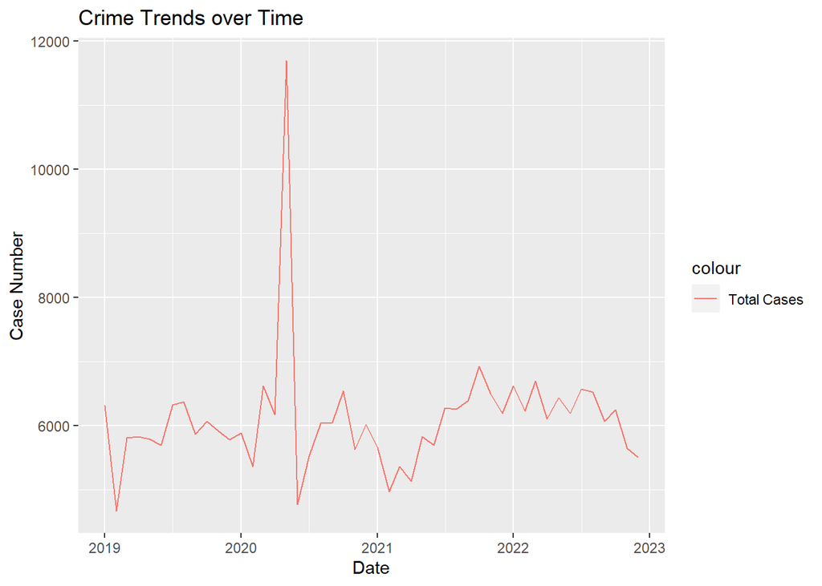

```r
par(mfrow = c(1, 2))
ggplot(Crime, aes(x = Date)) +
  geom_line(aes(y = TotalCases, color = "Total Cases")) +
  labs(title = "Crime Trends over Time", x = "Date", y = "Case Number")
```

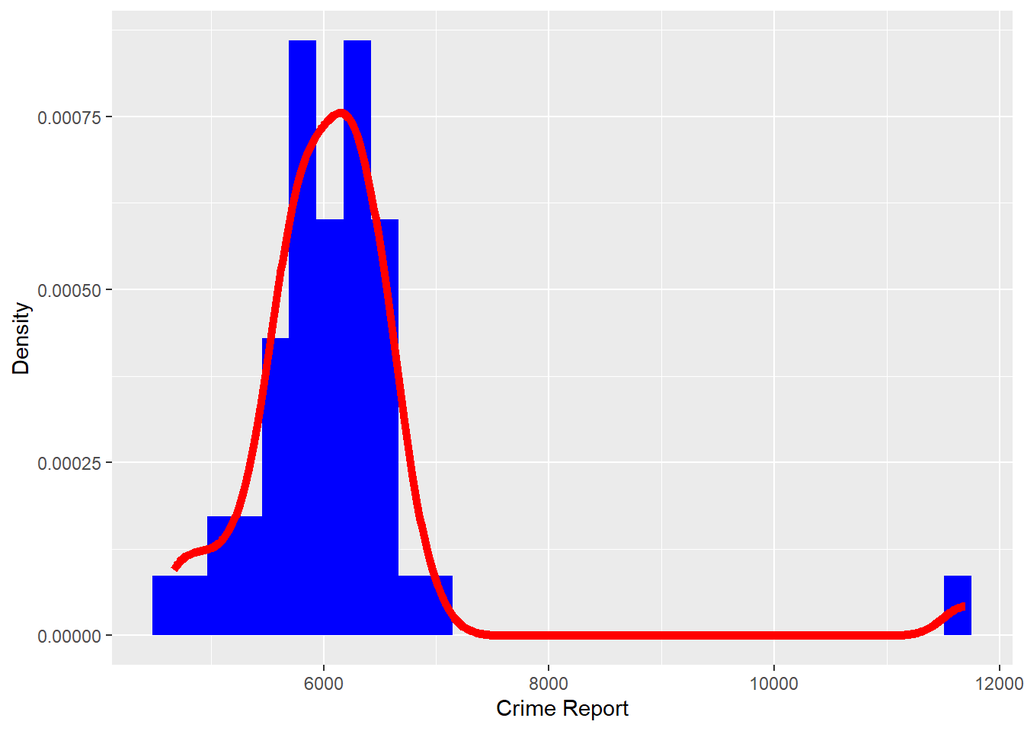

```r
ggplot(Crime, aes(x = TotalCases)) +
  geom_histogram(aes(y = ..density..), fill = "blue") + # Adjust binwidth as needed
  geom_density(colour = "red", size = 2) + # Adjust the size for line thickness
  labs(x = "Crime Report", y = "Density")
```

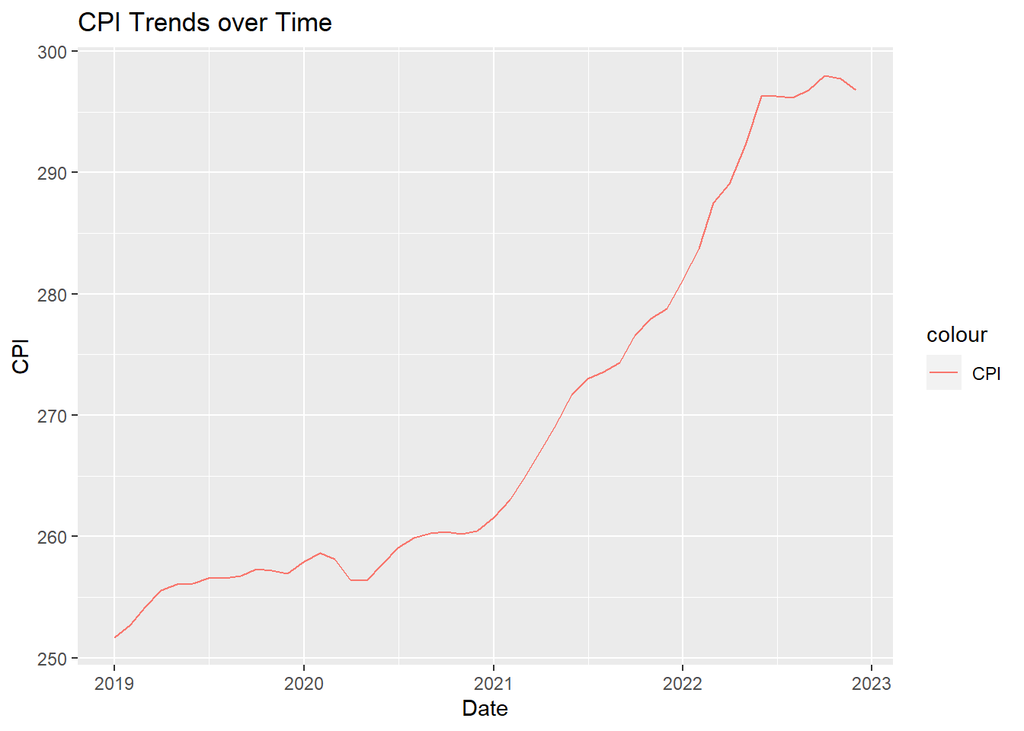

```r
ggplot(CPI, aes(x = Date)) +
  geom_line(aes(y = CPI, color = "CPI")) +
  labs(title = "CPI Trends over Time", x = "Date", y = "CPI")
```

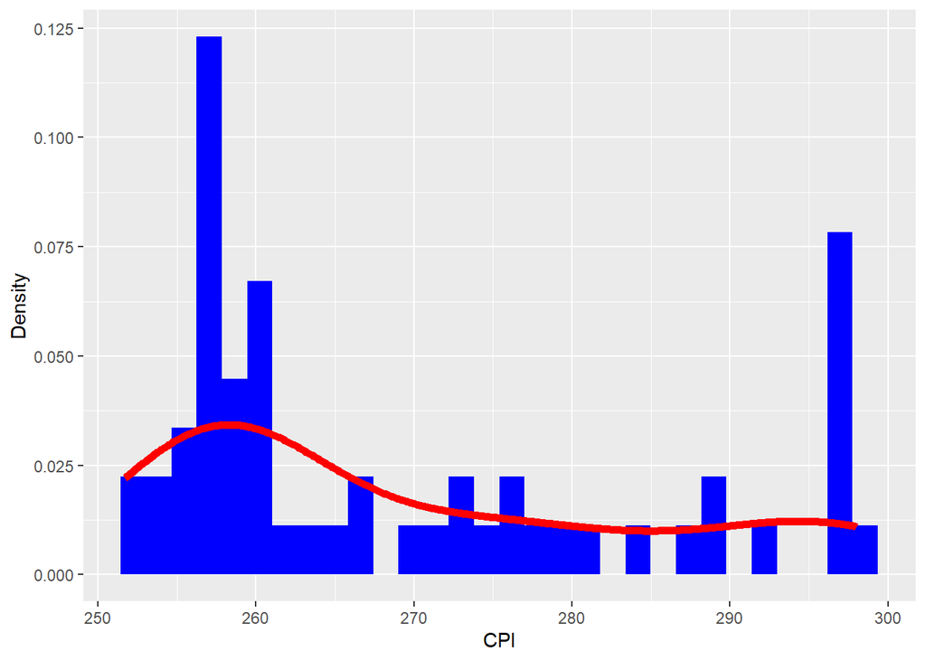

```r
ggplot(CPI, aes(x = CPI)) +
  geom_histogram(aes(y = ..density..), fill = "blue") + # Adjust binwidth as needed
  geom_density(colour = "red", size = 2) + # Adjust the size for line thickness
  labs(x = "CPI", y = "Density")
```

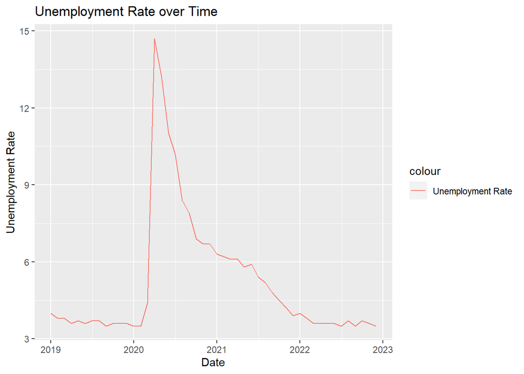

```r
ggplot(Unemp, aes(x = Date)) +
  geom_line(aes(y = Unemployment_rate, color = "Unemployment Rate")) +
  labs(title = "Unemployment Rate over Time", x = "Date", y = "Unemployment Rate")
```

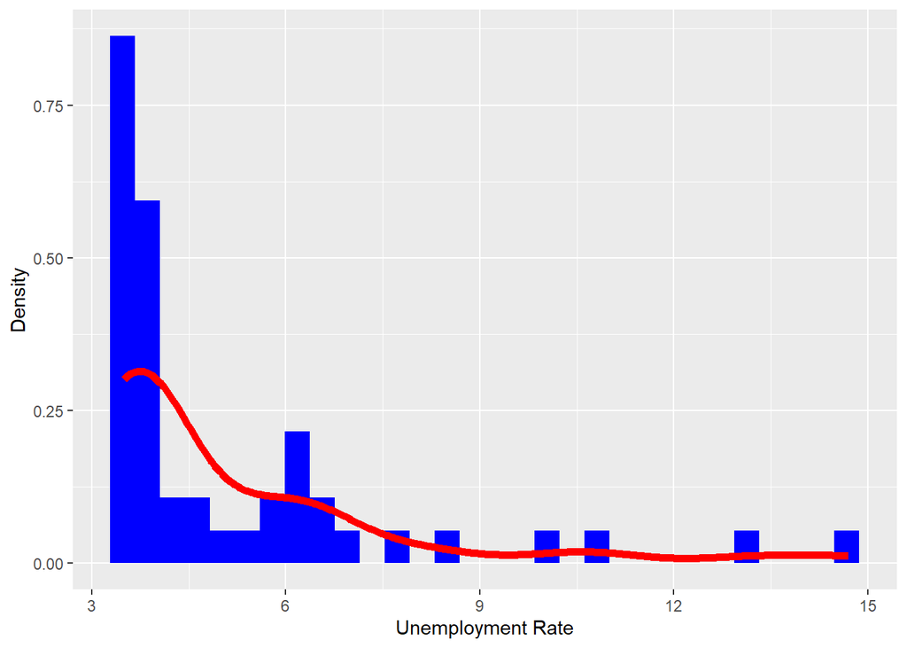

```r
ggplot(Unemp, aes(x = Unemployment_rate)) +
  geom_histogram(aes(y = ..density..), fill = "blue") + # Adjust binwidth as needed
  geom_density(colour = "red", size = 2) + # Adjust the size for line thickness
  labs(x = "Unemployment Rate", y = "Density")
```

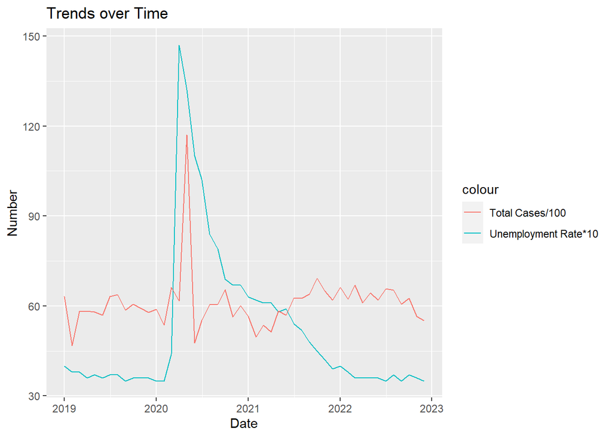

```r
ggplot(merged_crime, aes(x = Date)) +
  geom_line(aes(y = Unemployment_rate*10, color = "Unemployment Rate*10")) +
  geom_line(aes(y = TotalCases/100, color = "Total Cases/100")) +
  labs(title = "Trends over Time", x = "Date", y = "Number")
```

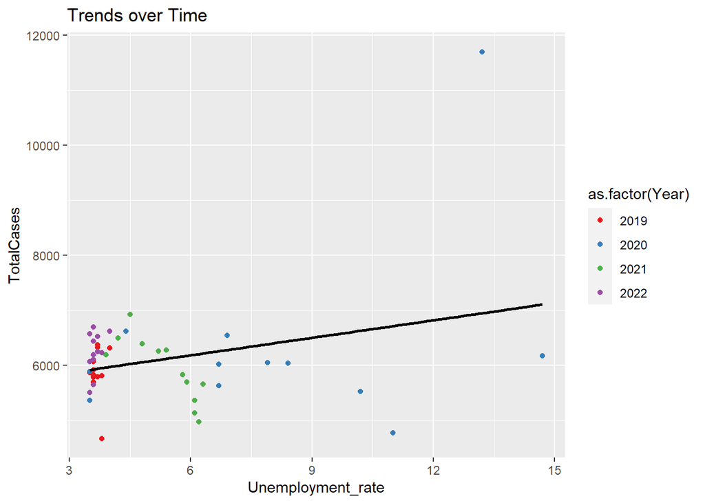

```r
ggplot(merged_crime, aes(x = Unemployment_rate, y = TotalCases, color = as.factor(Year))) +
  geom_point() +
  geom_smooth(method=lm, se=FALSE, color="black") +
  scale_color_brewer(type = "qual", palette = "Set1") +
  labs(title = "Trends over Time", x = "Unemployment_rate", y = "TotalCases")
```

# Map creating of Crime Report and Capital income in 2021

```r
Crime_Data <- read.csv("project data/crime_rate_2019_2022.csv")
Crime <- Crime_Data %>%
  select("Offense.ID", "Time" = "Report.DateTime", "Longitude", "Latitude") %>%
  filter(Latitude != 89.99999 & Latitude != 0)
Crime$Time <- mdy_hms(Crime$Time)
Crime <- Crime %>%
  filter(year(Time) == 2021)
head(Crime, 3)
```

```
##    Offense.ID                Time Longitude Latitude
## 1 19260363069 2021-01-03 21:17:54 -122.2915 47.71551
## 2 20409706356 2021-02-07 19:37:11 -122.3447 47.70505
## 3 21421289970 2021-02-23 17:27:31 -122.4113 47.57893
```

This data is a Crime report data, recording peoples reporting crime, Here I reshaped the dataset, renaming columns to make them more intuitive. Then I applied an additional filter to exclude records where the Latitude is 89.99999 or 0. These values are likely to be placeholders or errors. Then I used the mdy_hms() function to filter the year to 2021, because income data is in 2021.

Reference: SPD Crime Data: 2008-Present https://data.seattle.gov/Public-Safety/SPD-Crime-Data-2008-Present/tazs-3rd5

```r
Income_data <- read.csv("PER_CAPITA_INCOME.csv")
income <- Income_data %>%
  select("GEOID", "capital_income")
nrow(Income_data)# data size: number of rows and columns
```

```
## [1] 494
```

```r
ncol(Income_data)
```

```
## [1] 6
```

```r
write.csv(income, "capital_income.csv", row.names = FALSE)
```

This data is a monthly income data in 2021.I selected the “GEOID” as a Geopetry factor for data merging outside in QGIS(an geometry map for processing map data), and a “capital_income” data for analysis. Then I exported it to merge with a census tract shape file for mapping.

Cartographic Boundary Files https://www.census.gov/geographies/mapping-files/time-series/geo/cartographic-boundary.html PER CAPITA INCOME and AGGREGATE INCOME IN THE PAST 12 MONTHS (IN INFLATION-ADJUSTED DOLLARS) https://data.seattle.gov/dataset/PER-CAPITA-INCOME-and-AGGREGATE-INCOME-IN-THE-PAST/bkdj-yb3f

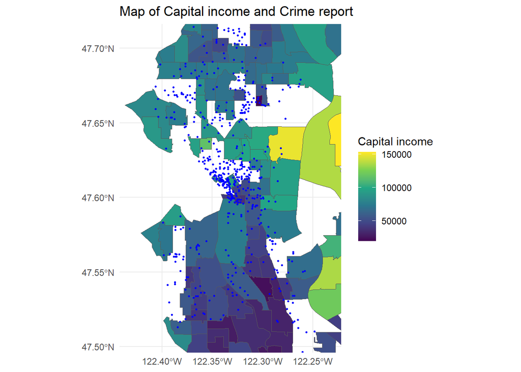

```r
Map_data <- st_read("income.shp")
Map_data <- Map_data %>% filter(!is.na(capital_in))
Map_data$capital_in <- as.numeric(Map_data$capital_in)
Crime_sf <- st_as_sf(Crime, coords = c("Longitude", "Latitude"), crs = st_crs(Map_data))

set.seed(123) # Set a seed for randomlizing the data
sample_size <- 0.01 # for map displaying, take 1% of the data
Crime_sampled <- Crime_sf[sample(nrow(Crime_sf), nrow(Crime_sf) * sample_size), ]

seattle_center <- c(-122.3321, 47.6062) # set coordinates for Seattle
range <- 0.1 # This sets the range around the center

final_plot <- ggplot() +
  geom_sf(data = Map_data, aes(fill = capital_in)) +
  geom_sf(data = Crime_sampled, color = "blue", size = 0.5) +
  coord_sf(xlim = c(seattle_center[1] - range, seattle_center[1] + range),
           ylim = c(seattle_center[2] - range, seattle_center[2] + range)) +
  scale_fill_viridis_c() +
  labs(title = "Map of Capital income and Crime report",
       fill = "Capital income") +
  theme_minimal()

print(final_plot)
```

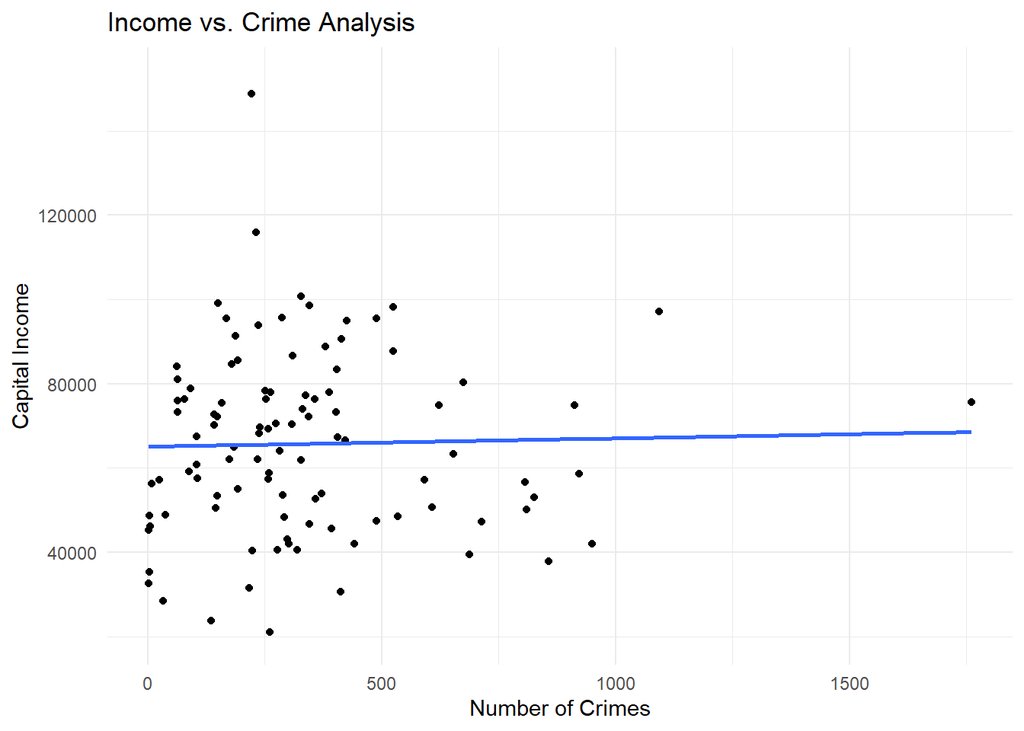

```r
Map_data <- Map_data %>%
  filter(!is.na(capital_in)) %>%
  mutate(capital_in = as.numeric(capital_in))

Map_data_validity <- st_is_valid(Map_data, NA_on_exception = TRUE)
if(any(!Map_data_validity, na.rm = TRUE)) {
  #fix invalid geometries
  Map_data <- st_make_valid(Map_data)
}

Crime_data_joined <- st_join(Crime_sf, Map_data)

# Aggregate crime data by area
Crime_by_area <- Crime_data_joined %>%
  group_by(GEOID) %>%
  summarise(crime_count = n())

Map_data_with_crime <- Map_data %>%
  st_join(Crime_by_area)

ggplot(Map_data_with_crime, aes(x = crime_count, y = capital_in)) +
  geom_point() +
  geom_smooth(method = "lm", se = FALSE) + # Add a regression line without standard error
  labs(x = "Number of Crimes", y = "Capital Income", title = "Income vs. Crime Analysis") +
  theme_minimal()
```